# R Notebook

Распределение p-value для фейковых деревьев (полученных переразбрасыванием мутаций) должно быть равномерным. Проверим, так ли это. Исходный файл получен скриптом grep_fdr.pl, который суммирует данные из папок evopoisson/output/fake_test/nsyn/maxpath_not_subtracted/fdr_fake_somenumber, порожденные FDR_all.pl)

```r
cs <- read.csv("C:/Users/weidewind/Documents/CMD/Coevolution/Influenza/environment_or_epistasis/sanityCheck/h1_460new_fdr")
r <- cs[cs$restr == 100 & cs$stat == "median_stat", ]
d <- r[r$env <=0.1,]
d
```

|  | group | restriction | stat | epi | env |
| --- | --- | --- | --- | --- | --- |
| 805 | all | 100 | median_stat | 0.9673 | 0.0329 |
| 925 | all | 100 | median_stat | 0.9227 | 0.0834 |
| 961 | all | 100 | median_stat | 0.9276 | 0.0843 |
| 1201 | all | 100 | median_stat | 0.9166 | 0.0980 |
| 1291 | all | 100 | median_stat | 0.9339 | 0.0776 |
| 1597 | all | 100 | median_stat | 0.9937 | 0.0067 |
| 1663 | all | 100 | median_stat | 0.9353 | 0.0749 |
| 1711 | all | 100 | median_stat | 0.9180 | 0.0943 |
| 1765 | all | 100 | median_stat | 0.9223 | 0.0862 |
| 1849 | all | 100 | median_stat | 0.9256 | 0.0895 |

[output cut: 4 more lines]

```r
draw_hists <- function(file, restriction, stat){
    cs <- read.csv(file)
    r <- cs[cs$restr == restriction & cs$stat == stat, ]
    hist(r$epi, breaks=30)
    hist(r$env, breaks=30)
}
```

Распределение p-values для фейковых наблюдений (белок целиком) - для 200 наблюдений, 10000 итераций

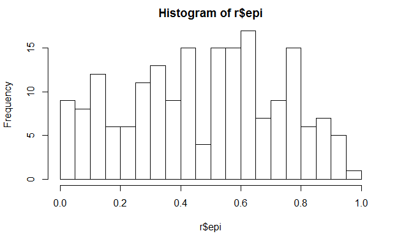

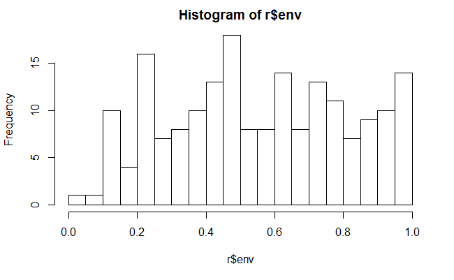

```r
draw_hists("C:/Users/weidewind/Documents/CMD/Coevolution/Influenza/environment_or_epistasis/sanityCheck/h1_200_fdr", 100,"median_stat")
```

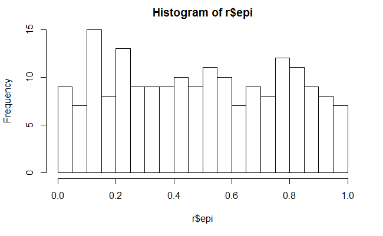

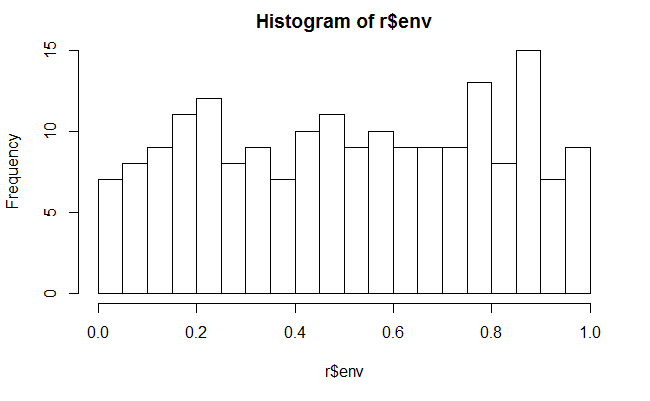

```r
draw_hists("C:/Users/weidewind/Documents/CMD/Coevolution/Influenza/environment_or_epistasis/sanityCheck/h1_200_fdr", 100,"mean_stat")
```

То же для 1000 наблюдений, 10000 итераций Вторая строка: 500 наблюдений, 5000 итераций, новые итерации (fake_new_iterations) Третья строка: 500 наблюдений, 5000 итераций, новые итерации, при каждой итерации создается новый клон (fake_new_clones)

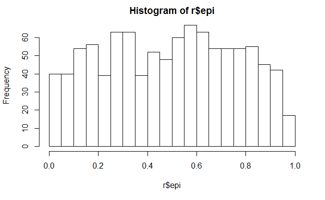

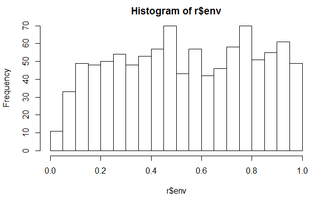

```r
draw_hists("C:/Users/weidewind/Documents/CMD/Coevolution/Influenza/environment_or_epistasis/sanityCheck/h1_allnew_fdr", 100,"median_stat")
```

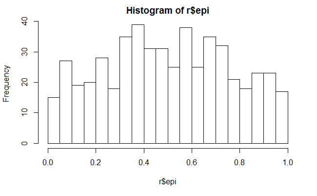

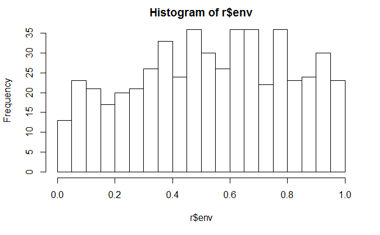

```r
draw_hists("C:/Users/weidewind/Documents/CMD/Coevolution/Influenza/environment_or_epistasis/sanityCheck/h1_allnew_iterations_fdr", 50,"median_stat")
```

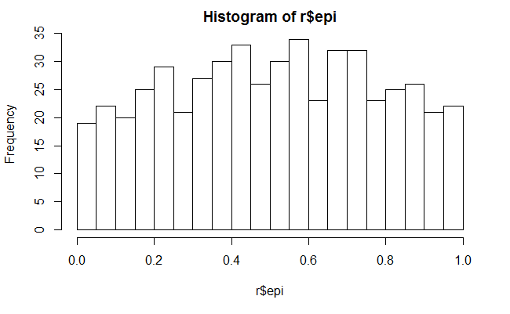

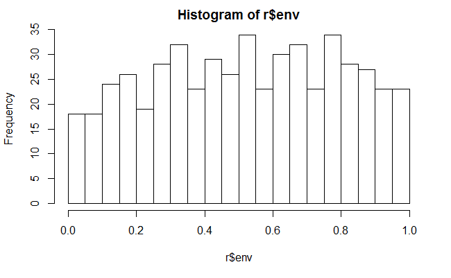

```r
draw_hists("C:/Users/weidewind/Documents/CMD/Coevolution/Influenza/environment_or_epistasis/sanityCheck/h1_allnew_iterations_fdr", 150,"median_stat")
```

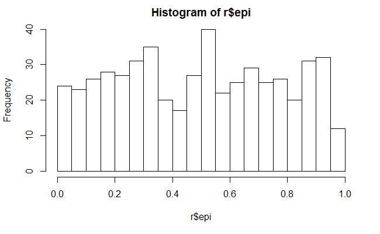

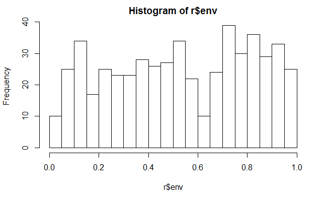

```r
draw_hists("C:/Users/weidewind/Documents/CMD/Coevolution/Influenza/environment_or_epistasis/sanityCheck/h1_allnew_clones_fdr", 100,"median_stat")
```

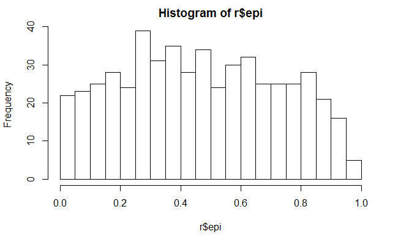

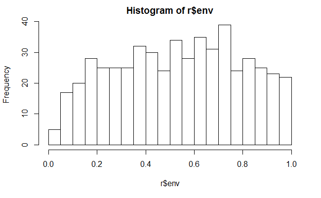

```r
#draw_hists("C:/Users/weidewind/Documents/CMD/Coevolution/Influenza/environment_or_epistasis/sanityCheck/h1_allnew_fdr", 50,"mean_stat")
draw_hists("C:/Users/weidewind/Documents/CMD/Coevolution/Influenza/environment_or_epistasis/sanityCheck/h1_allnew_iterations_fdr", 50,"mean_stat")
```

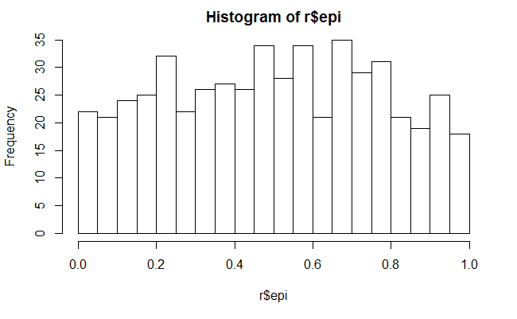

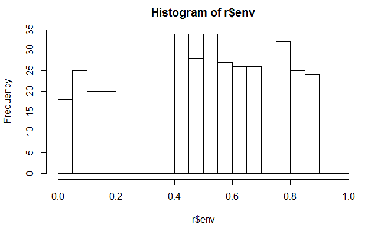

```r
#draw_hists("C:/Users/weidewind/Documents/CMD/Coevolution/Influenza/environment_or_epistasis/sanityCheck/h1_allnew_clones_fdr", 50,"mean_stat")
#draw_hists("C:/Users/weidewind/Documents/CMD/Coevolution/Influenza/environment_or_epistasis/sanityCheck/h1_allnew_fdr", 150,"mean_stat")
draw_hists("C:/Users/weidewind/Documents/CMD/Coevolution/Influenza/environment_or_epistasis/sanityCheck/h1_allnew_iterations_fdr", 100,"mean_stat")
```

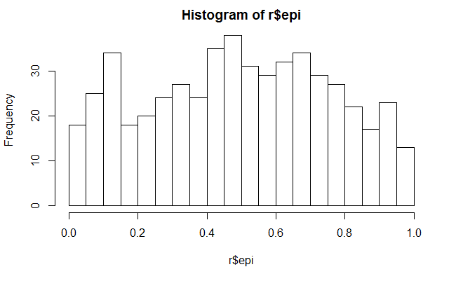

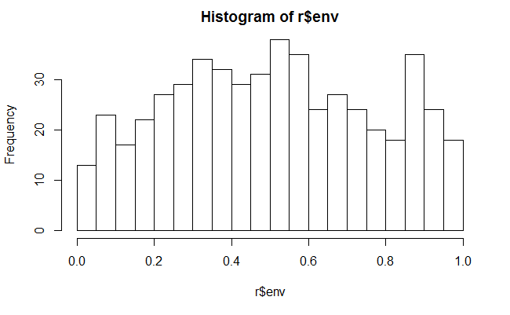

```r
draw_hists("C:/Users/weidewind/Documents/CMD/Coevolution/Influenza/environment_or_epistasis/sanityCheck/h1_allnew_iterations_fdr", 150,"mean_stat")
```

[output not shown]

```r
#draw_hists("C:/Users/weidewind/Documents/CMD/Coevolution/Influenza/environment_or_epistasis/sanityCheck/h1_allnew_clones_fdr", 150,"mean_stat")
```

Посмотрим на распределение самой статистики (взята из файла fdr_fake_1(или 10)/h1_gulpselector_vector_boot_median_test_100_all), может быть, есть (не)естественное ограничение на ее значения, и все экстремальные значения скапливаются в точке этого минимума? Это объяснило бы, почему так мало маленьких p-value. Но нет, распределение выглядит пристойно, непонятно, как из таких красивых, слюшай, распределений получаются столь неравномерные распределения pvalue

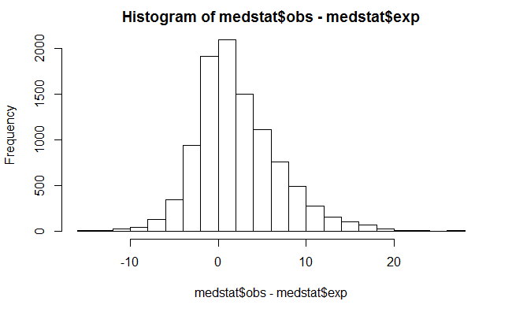

```r
medstat<-read.csv("C:/Users/weidewind/Documents/CMD/Coevolution/Influenza/environment_or_epistasis/sanityCheck/h1_boot_median_stats_fake_1.txt")
hist(medstat$obs-medstat$exp, breaks = 20)
```

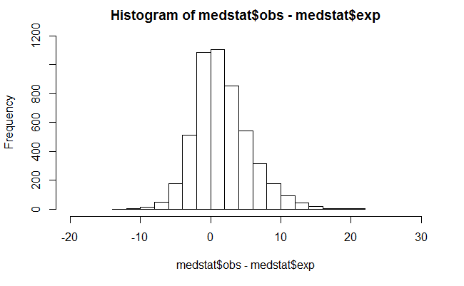

```r
medstat<-read.csv("C:/Users/weidewind/Documents/CMD/Coevolution/Influenza/environment_or_epistasis/sanityCheck/fake_new_iterations/fake_1_50_median.txt")
hist(medstat$obs-medstat$exp, breaks = 20, xlim= range(-20, 30), ylim = range(0,1200))
```

```r
mean(medstat$obs-medstat$exp)
```

```
[1] 1.85075
```

```r
min(medstat$obs-medstat$exp)
```

```
[1] -14
```

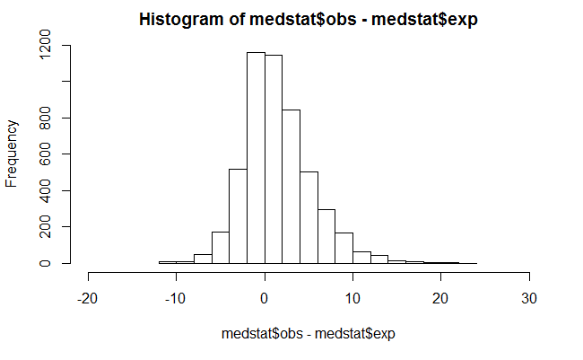

```r
medstat<-read.csv("C:/Users/weidewind/Documents/CMD/Coevolution/Influenza/environment_or_epistasis/sanityCheck/fake_new_iterations/fake_10_50_median.txt")
hist(medstat$obs-medstat$exp, breaks = 20, xlim= range(-20, 30), ylim = range(0,1200))
```

```r
mean(medstat$obs-medstat$exp)
```

```
[1] 1.7058
```

```r
min(medstat$obs-medstat$exp)
```

```
[1] -12
```

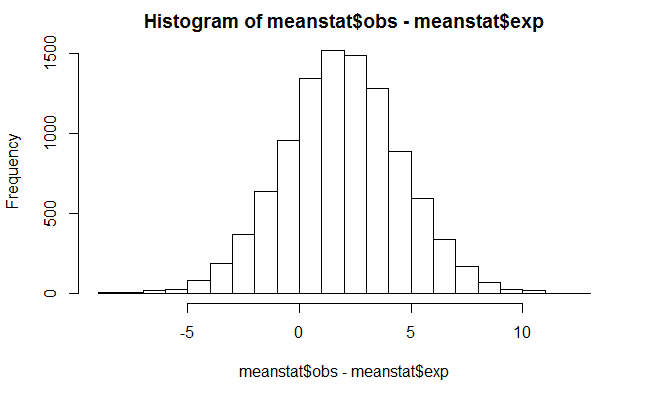

```r
meanstat<-read.csv("C:/Users/weidewind/Documents/CMD/Coevolution/Influenza/environment_or_epistasis/sanityCheck/h1_boot_mean_stats_fake_1.txt")
hist(meanstat$obs-meanstat$exp, breaks = 20)
```

```r
var(meanstat$obs-meanstat$exp)
```

```
[1] 6.973423
```

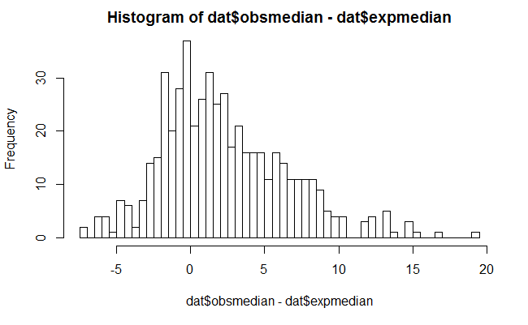

```r
dat<-read.csv("C:/Users/weidewind/Documents/CMD/Coevolution/Influenza/environment_or_epistasis/sanityCheck/h1_allnew_iterations_fdr")
dat<- dat[dat$restr==100 & dat$stat == "median_stat",]
lowpval <-dat[dat$env<0.05,]
hist(dat$obsmedian-dat$expmedian,breaks=40)
```

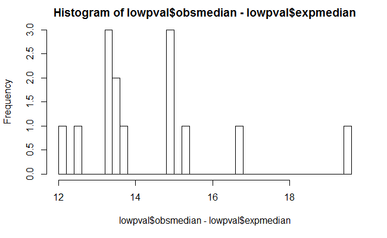

```r
hist(lowpval$obsmedian-lowpval$expmedian,breaks=40)
```

Распределения статистик фейков и симуляций вроде похожи, но что там с левым хвостом? Распределение статистики для симуляции, внимание, взято для одного фейкового наблюдения

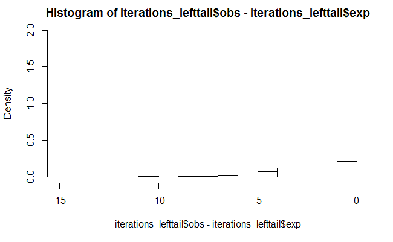

```r
medstat<-read.csv("C:/Users/weidewind/Documents/CMD/Coevolution/Influenza/environment_or_epistasis/sanityCheck/fake_new_iterations/fake_10_50_median.txt")
dat<-read.csv("C:/Users/weidewind/Documents/CMD/Coevolution/Influenza/environment_or_epistasis/sanityCheck/h1_allnew_iterations_fdr")
dat<- dat[dat$restr==50 & dat$stat == "median_stat",]
iterations_lefttail <-medstat[medstat$obs-medstat$exp < 0,]
hist(iterations_lefttail$obs-iterations_lefttail$exp, breaks = 10, xlim= range(-15, 0), ylim = range(0,2),freq=FALSE)
```

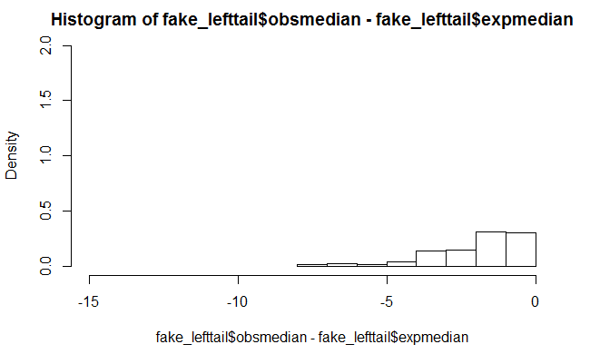

```r
fake_lefttail <- dat[dat$obsmedian-dat$expmedian < 0,]
hist(fake_lefttail$obsmedian-fake_lefttail$expmedian,breaks=10, xlim= range(-15, 0), ylim = range(0,2),freq=FALSE)
```

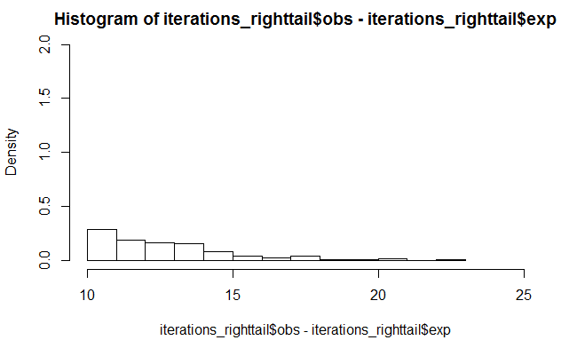

```r
iterations_righttail <-medstat[medstat$obs-medstat$exp > 10,]
hist(iterations_righttail$obs-iterations_righttail$exp, breaks = 10, xlim= range(10, 25), ylim = range(0,2),freq=FALSE)
```

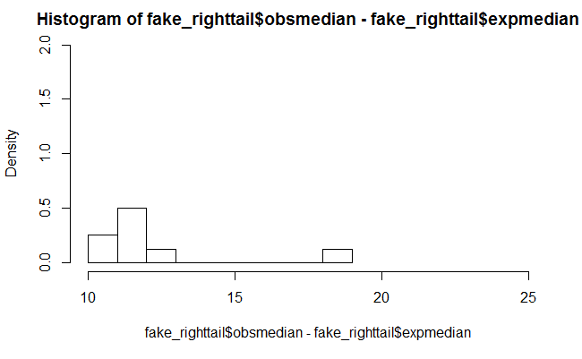

```r
fake_righttail <- dat[dat$obsmedian-dat$expmedian > 10,]
hist(fake_righttail$obsmedian-fake_righttail$expmedian,breaks=10, xlim= range(10, 25), ylim = range(0,2),freq=FALSE)
```

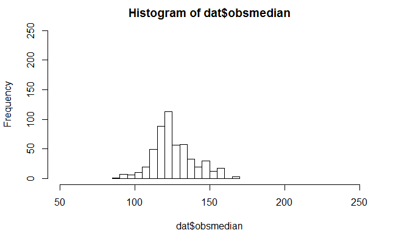

```r
hist(dat$obsmedian,breaks=20, ylim=range(0:250), xlim=range(50:250))
```

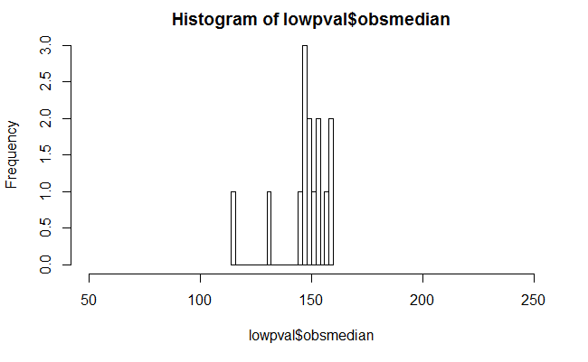

```r
hist(lowpval$obsmedian,breaks=20,  xlim=range(50:250))
```

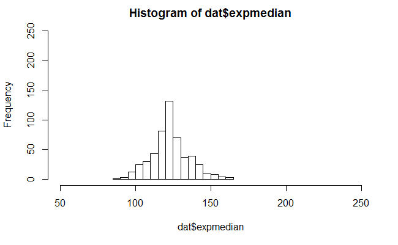

```r
hist(dat$expmedian,breaks=20, ylim=range(0:250), xlim=range(50:250))
```